# Coursework 2 - Part 1

**Replace CID in the file name with your CID**

# Outline

- Task 1: Classification with a Convolutional Neural Network
  - (1.1)
  - (1.2)
  - (1.3)
- Task 2: Dimensionality Reduction: PCA vs ISOMAP
  - (2.1)
  - (2.2)
  - (2.3)

```python
import matplotlib.pyplot as plt
import numpy as np
import pandas as pd
import torch


# Importing losses, activation functions and layers from PyTorch
from torch.nn import Sequential, CrossEntropyLoss, Conv1d, MaxPool1d, Flatten, Linear, ReLU, Softmax, Parameter, Conv2d, MaxPool2d
from torch.utils.data import TensorDataset, DataLoader
from scipy.sparse import linalg
```

# (1) Task 1: Classification with a Convolutional Neural Network (index)

In this task, I will randomrize the data by shuffling them and the split it into trainnign and validation test and create a CNN model accroing to the intrusction given(also preparing for R2 regularizing), monitor the trainng performace by computing classifcation accuracy for each epoch for the trainning and validation set and comment on the CNN performance in general.

```python
Images_train = np.load('C:\\Users\\sam\\imperial\\Year3\\Data sciecne\\CW2\\star_images_train.npy')
Images_test = np.load('C:\\Users\\sam\\imperial\\Year3\\Data sciecne\\CW2\\star_images_test.npy')
Classes_train = np.load('C:\\Users\\sam\\imperial\\Year3\\Data sciecne\\CW2\\star_classes_train.npy')
Classes_test = np.load('C:\\Users\\sam\\imperial\\Year3\\Data sciecne\\CW2\\star_classes_test.npy')
Embeds_train = np.load('C:\\Users\\sam\\imperial\\Year3\\Data sciecne\\CW2\\star_embeddings_train.npy')


# shuffle data
np.random.seed(0)
N = len(Classes_train)
permutation = np.random.choice(N, size=N, replace=False)
Classes_train = Classes_train[permutation]
Images_train = Images_train[permutation, :, :]
Embeds_train = Embeds_train[permutation, :]

#split the data
split_rate = 0.75
Images_tr, Images_val = np.split(Images_train, [int(split_rate*N)])
Classes_tr, Classes_val = np.split(Classes_train, [int(split_rate*N)])
Images_tr = Images_tr[:, np.newaxis, :] # added an axis for CNN
Images_test = Images_test[:, np.newaxis, :]
Images_val = Images_val[:, np.newaxis, :]
Images_train = Images_train[:, np.newaxis, :]
print(Images_test.shape)
```

```
(32, 1, 32, 32)
```

```python
def get_model(x_train, first_filters, second_filters, kernel_size, pool_size, stride_pool, classes, l2_reg=1e-3,weight_decay=0):
    """
    CNN model in PyTorch:
    - Layers are Conv2d(+ReLU), MaxPool2d, Conv2d(+ReLU), Flatten and Linear(+Softmax).
    - It features an Adam optimiser and CrossEntropyLoss criterion.
    - Conv2d and Linear layers have regularised weights according to l2_reg.

    Parameters:
    x_train: Training data
    first_filters: Number of filters to be used in the first convolutional layer
    second_filters: Number of filters to be used in the second convolutional layer
    k: Kernel size in the convolutional layer
    pool_size: MaxPool1d window size
    stride_pool: Stride of the MaxPool1d sliding window
    classes: List containing the output classes
    l2_reg: Positive float corresponding to the regularisation coefficient of Conv1d and Linear
    weight_decay: a parameter only used when R2 regularization is neeeded

    Returns:
    Model, criterion and optimiser.

    """
    k = np.asarray(kernel_size)
    p = np.asarray(pool_size)
    l_out_conv1 = [x_train.shape[2], x_train.shape[3]] - k + [1, 1] # dimention after first Conv2d (note that the stride is 1)
    l_out_pool = (l_out_conv1 - p) // stride_pool + [1, 1] # Length after MaxPool2d
    l_out_conv2 = l_out_pool - k + [1, 1]
    l_in_linear = second_filters * l_out_conv2[0] * l_out_conv2[1] # Size before Linear layer

    model = Sequential(
        Conv2d(1, first_filters, kernel_size=(5, 5)),
        ReLU(),
        MaxPool2d(kernel_size=pool_size, stride=stride_pool),
        Conv2d(first_filters , second_filters, kernel_size=(5, 5)),
        ReLU(),
        Flatten(),
        Linear(l_in_linear, len(classes)),
        Softmax(dim=1),
    )
    # L2 regularisation for 2.2
    if l2_reg != 0:
        for layer in model.children():
            if isinstance(layer, Conv2d):
                 layer.weight_regularizer = Parameter(l2_reg * torch.ones_like(layer.weight))

    criterion = CrossEntropyLoss()

    if weight_decay == 0:
        optimiser = torch.optim.Adam(model.parameters())
    else:
        optimiser = torch.optim.Adam(model.parameters(), weight_decay=weight_decay) #special case in R2 regularization


    return model, criterion, optimiser
```

```python
# Numpy arrays to PyTorch tensors
Images_tr_tensor = torch.tensor(Images_tr, dtype=torch.float32)
Classes_tr_tensor = torch.tensor(Classes_tr)
Images_val_tensor = torch.tensor(Images_val, dtype=torch.float32)
Classes_val_tensor = torch.tensor(Classes_val)

# Creating training and validation datasets
train_dataset = TensorDataset(Images_tr_tensor, Classes_tr_tensor.squeeze())
val_dataset = TensorDataset(Images_val_tensor, Classes_val_tensor.squeeze())

# Creating corresponding DataLoaders
train_loader = DataLoader(train_dataset, batch_size=128, shuffle=True)
val_loader = DataLoader(val_dataset, batch_size=128, shuffle=False)
```

```python
class EarlyStopping:
    """
    EarlyStopping class.

    Attributes:
    max_patience: Amount of epochs with no improvement after which training is stopped.
    patience: Stores the number of epochs with no improvement.
    best_valid_loss: Stores the current value of the best (minimum) validation loss.
    early_stop: True if training needs to be stopped due to the early stopping condition being met.

    Methods:
    step(val_loss):
        Checks current state after an epoch and updates best_loss, patience and early_stop accordingly.
    """

    def __init__(self, max_patience=5):
        self.max_patience = max_patience
        self.patience = 0
        self.best_valid_loss = float('inf')
        self.early_stop = False

    def step(self, val_loss):
        if val_loss < self.best_valid_loss:
            self.best_valid_loss = val_loss
            self.patience = 0
        else:
            self.patience += 1
            if self.patience >= self.max_patience:
                self.early_stop = True
```

```python
def training_loop(model, train_loader, val_loader, max_num_epochs=200, max_patience=5, printing_or_not=True):
    """
    Training loop with early stopping to monitor the validation accuracy.

    Parameters:
    train_loader: Training DataLoader
    val_loader: Validation DataLoader
    max_num_epochs: Maximum number of epochs
    max_patience: max_patience attribute of the EarlyStopping class
    printing_or_not: a boolean determine whether we print the accuracy of the trainning set and validation during trainning.

    Returns:
    Model, criterion and optimiser.

    """

    history = {'training_loss': [], 'validation_loss': [], 'training_accuracy': [], 'validation_accuracy': []}
    early_stopping = EarlyStopping(max_patience=max_patience)

    for epoch in range(max_num_epochs):

        tr_loss = 0.0
        tr_accuracy = 0
        val_loss = 0.0
        val_accuracy = 0

        # Training
        model.train()
        for inputs, labels in train_loader:
            optimiser.zero_grad() # Setting gradients to zero
            outputs = model(inputs)
            loss = criterion(outputs, labels)
            tr_loss += loss.item()
            tr_accuracy += (torch.max(outputs, 1)[1] == labels).sum().item() / (len(train_loader) * labels.size(0))  ## <-- SOLUTION
            loss.backward() # Computes gradients of the loss
            optimiser.step() # Optimisation step (parameters are updated)

        history['training_loss'].append(tr_loss/len(train_loader))
        history['training_accuracy'].append(100*tr_accuracy)

        # Validation
        model.eval()
        with torch.no_grad():
            for inputs, labels in val_loader:
                outputs = model(inputs)
                loss = criterion(outputs, labels)
                val_loss += loss.item()
                val_accuracy += (torch.max(outputs, 1)[1] == labels).sum().item() / (len(val_loader) * labels.size(0))

        history['validation_loss'].append(val_loss/len(val_loader))
        history['validation_accuracy'].append(100*val_accuracy)

        # Calculate accuracy and print
        if printing_or_not:
            print(f"Epoch {epoch + 1}/{max_num_epochs}, Training loss: {tr_loss/len(train_loader)}, Training accuracy: {100*tr_accuracy}%, Validation loss: {val_loss/len(val_loader)}, Validation accuracy: {100*val_accuracy}%")

        # Check for early stopping
        early_stopping.step(val_loss / len(val_loader))
        if early_stopping.early_stop:
            print("Early stopping acting.")
            break

    return history
```

```python
# Run the function to get the model and print it

first_filters = 4
second_filters = 8
kernel_size = (5, 5)
pool_size = (2, 2)
stride_pool = 2
l2_reg = 0
classes = np.unique(Classes_tr)

model, criterion, optimiser = get_model(Images_tr, first_filters, second_filters, kernel_size, pool_size, stride_pool, classes, l2_reg) #we create a new model each time to avoid over-trainning(train the trained model again).


# Calling the training loop
max_num_epochs = 2000
max_patience = 150

history = training_loop(model, train_loader, val_loader, max_num_epochs, max_patience)
```

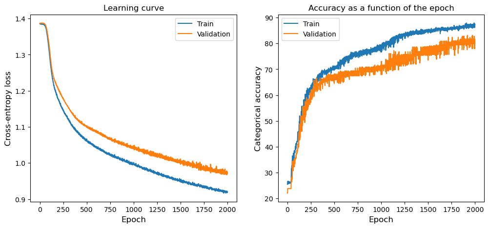

```python
# Plot the learning curves

fig = plt.figure(figsize=(12, 5))

fig.add_subplot(121)
plt.plot(history['training_loss'], label='Train')
plt.plot(history['validation_loss'], label='Validation')
plt.xlabel("Epoch", size=12)
plt.ylabel("Cross-entropy loss", size=12)
plt.title("Learning curve")
plt.legend()

fig.add_subplot(122)
plt.plot(history['training_accuracy'], label='Train')
plt.plot(history['validation_accuracy'], label='Validation')
plt.xlabel("Epoch", size=12)
plt.ylabel("Categorical accuracy", size=12)
plt.title("Accuracy as a function of the epoch")
plt.legend()

plt.show()
```

We can see that the trainning converges pretty well, as on the plot above we can seee that, the cross-entropy loss converge exponentially for a period of time then gradgually reaching a plateau, and so is the catergoiral accuracy as on the plot, we can see that the categorial accuracy reaching a plateau at aroun 0.8 categorial accuracy, which is quite a good accuracy for validation set as it quite fit the data and not yet overfit yet.

```python
# Get the model predictions
preds = model(torch.tensor(Images_test, dtype=torch.float32)).detach().numpy()
```

```python
pred_class = [np.argmax(preds[i, :]) for i in range(preds.shape[0])]
accuracy_vector = (pred_class == Classes_test)
print("the classification accuracy on the test set is", accuracy_vector.sum()/len(accuracy_vector))
```

```
the classification accuracy on the test set is 0.8125
```

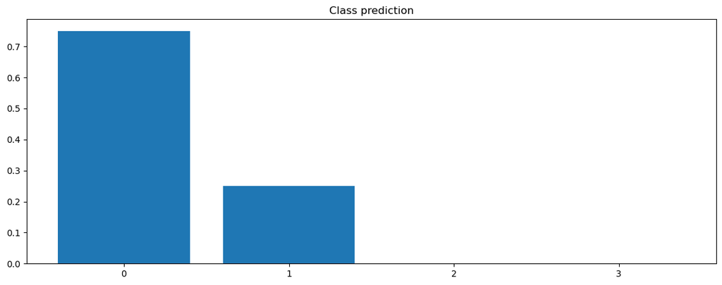

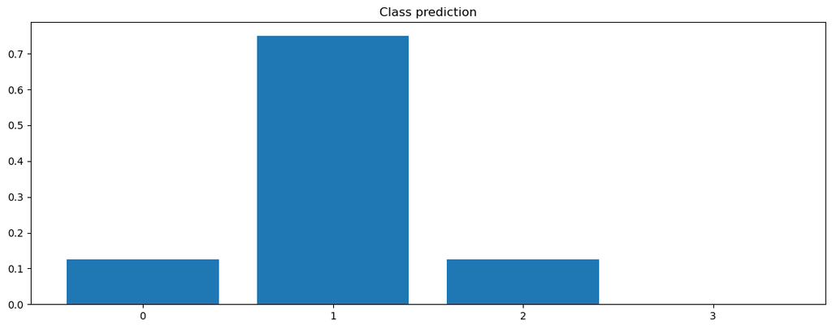

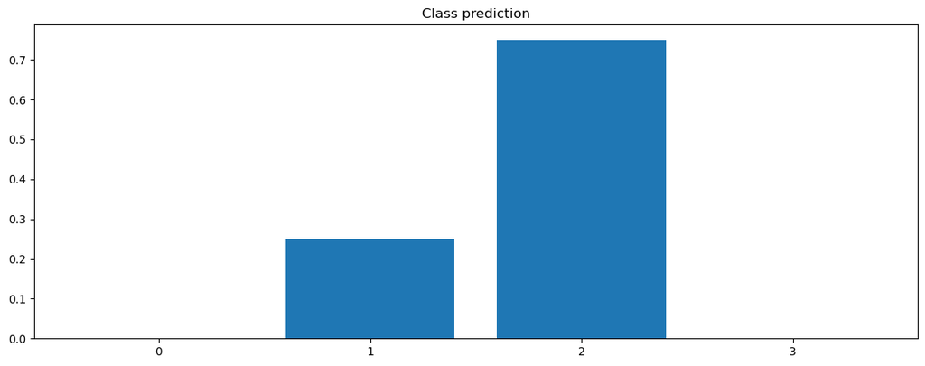

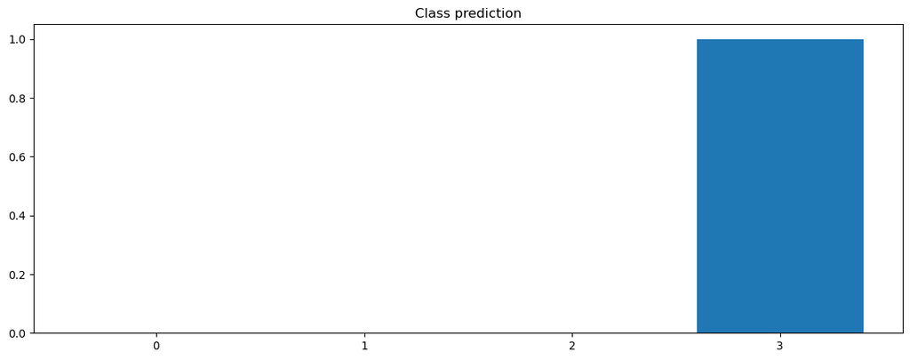

```python
#ploting the accuracy for each class
for i in range(4):
    fig, ax = plt.subplots(figsize = (14, 5))
    cnt = np.zeros(4)
    total = 0
    for j in range(len(Classes_test)):
        if Classes_test[j] == i:
            cnt[pred_class[j]] += 1
            total+=1
    ax.set_title('Class prediction')
    ax.bar(['0', '1', '2', '3'], cnt/total)
```

## (1.2) (index)

Note as in the code for 1.1, we have implemented the part for the l2 regularization, so we just have to test for different $\lambda$..

```python
#initializing
penalty_coefficient = [0.001, 0.01, 0.1, 1, 10]
accruacy_vecotor = np.zeros(len(penalty_coefficient))
penalty_model = [0, 0, 0, 0, 0] #initialize a list containing models with different penalty coefficient
accuracy_model = [0, 0, 0, 0, 0] #initialize a list containign the accruacy of all the models.
opt_penalty_coefficient = 0.001 #initial value could be arbitary
opt_accuracy = 0 #inital value could be arbitary

for i in range(5):
    #create a new model each time to avoid trainning a trained model and also adding regularization constant
    tmp_model, criterion, optimiser = get_model(Images_tr, first_filters, second_filters, kernel_size, pool_size, stride_pool, classes, l2_reg=penalty_coefficient[i],weight_decay=penalty_coefficient[i])

    # Calling the training loop
    max_num_epochs = 2000
    max_patience = 150

    history = training_loop(tmp_model, train_loader, val_loader, max_num_epochs, max_patience, printing_or_not=False)

    # Get the model predictions
    preds = tmp_model(torch.tensor(Images_val, dtype=torch.float32)).detach().numpy()
    pred_class = [np.argmax(preds[i, :]) for i in range(preds.shape[0])]
    accuracy_vector = (pred_class == Classes_val)
    print("the classification accuracy on the test set is", accuracy_vector.sum()/len(accuracy_vector))

    #finding the optimal accuracy.
    if accuracy_vector.sum()/len(accuracy_vector) > opt_accuracy:
        opt_accuracy = accuracy_vector.sum()/len(accuracy_vector)
        opt_penalty_coefficient = penalty_coefficient[i]
    penalty_model[i] = tmp_model
    accuracy_model[i] = accuracy_vector.sum()/len(accuracy_vector)
print('the optimal penalty coefficent =',opt_penalty_coefficient)
```

```
the classification accuracy on the test set is 0.9074074074074074
the classification accuracy on the test set is 0.8148148148148148
the classification accuracy on the test set is 0.9135802469135802
the classification accuracy on the test set is 0.8209876543209876
the classification accuracy on the test set is 0.8271604938271605
the optimal penalty coefficent = 0.1
```

```python
print("The optimal accuracy is", opt_accuracy)
print("The optimal penalty coefficient is", opt_penalty_coefficient)
```

```
The optimal accuracy is 0.9135802469135802
The optimal penalty coefficient is 0.1
```

```python
# retrain the model to get the new model with optimal penalty coefficent

first_filters = 4
second_filters = 8
kernel_size = (5, 5)
pool_size = (2, 2)
stride_pool = 2
l2_reg = opt_penalty_coefficient
weight_decay = opt_penalty_coefficient
classes = np.unique(Classes_tr)

opt_model, criterion, optimiser = get_model(Images_train, first_filters, second_filters, kernel_size, pool_size, stride_pool, classes, l2_reg, weight_decay)
print(opt_model)
```

```
Sequential(
  (0): Conv2d(1, 4, kernel_size=(5, 5), stride=(1, 1))
  (1): ReLU()
  (2): MaxPool2d(kernel_size=(2, 2), stride=2, padding=0, dilation=1, ceil_mode=False)
  (3): Conv2d(4, 8, kernel_size=(5, 5), stride=(1, 1))
  (4): ReLU()
  (5): Flatten(start_dim=1, end_dim=-1)
  (6): Linear(in_features=800, out_features=4, bias=True)
  (7): Softmax(dim=1)
)
```

```python
#create a train loader that USE ALL OF THE TRAINNING SET
# Numpy arrays to PyTorch tensors
Images_train_tensor = torch.tensor(Images_train, dtype=torch.float32)
Classes_train_tensor = torch.tensor(Classes_train)
Images_val_tensor = torch.tensor(Images_val, dtype=torch.float32)
Classes_val_tensor = torch.tensor(Classes_val)

# Creating training and validation datasets
train_dataset = TensorDataset(Images_train_tensor, Classes_train_tensor.squeeze())
val_dataset = TensorDataset(Images_val_tensor, Classes_val_tensor.squeeze())

# Creating corresponding DataLoaders
train_loader = DataLoader(train_dataset, batch_size=128, shuffle=True)
val_loader = DataLoader(val_dataset, batch_size=128, shuffle=False)

# Calling the training loop
max_num_epochs = 2000
max_patience = 150

history = training_loop(opt_model, train_loader, val_loader, max_num_epochs, max_patience) #the validation set is just to check the trainning process is converging or not
```

```python
# Get the model predictions ### need to train on the full data
preds = opt_model(torch.tensor(Images_test, dtype=torch.float32)).detach().numpy()
pred_class = [np.argmax(preds[i, :]) for i in range(preds.shape[0])]
accuracy_vector = (pred_class == Classes_test)
print("the classification accuracy on the test set is", accuracy_vector.sum()/len(accuracy_vector))
```

```
the classification accuracy on the test set is 0.9375
```

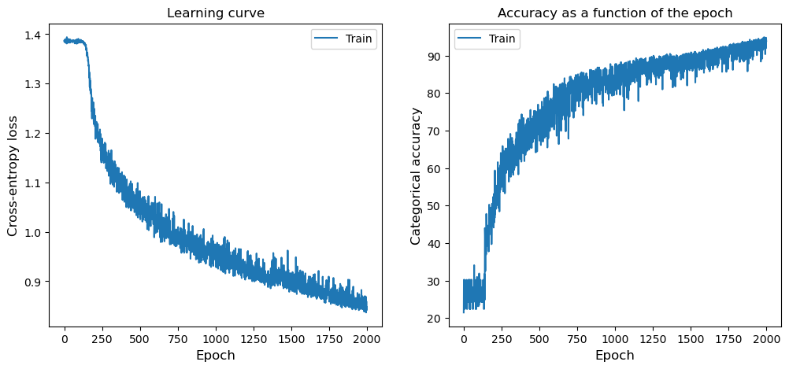

```python
# Plot the learning curves

fig = plt.figure(figsize=(12, 5))

fig.add_subplot(121)
plt.plot(history['training_loss'], label='Train')
plt.xlabel("Epoch", size=12)
plt.ylabel("Cross-entropy loss", size=12)
plt.title("Learning curve")
plt.legend()

fig.add_subplot(122)
plt.plot(history['training_accuracy'], label='Train')
plt.xlabel("Epoch", size=12)
plt.ylabel("Categorical accuracy", size=12)
plt.title("Accuracy as a function of the epoch")
plt.legend()

plt.show()
```

The performance of the trainning set with L2 regularization is definitely better than the one I did in 1.1 as the accuracy the testing set is around 0.94 this time which wtihout L2 regularization is around only 80%, this is due to a R2 regularizaiton has the effect of performing overfitting by shrinking weight magnitudes, that's why using the optimal penalty coeffiecnt yieds better class accuraucy, also we have tuned for the best penalty coefficeinet.

## (1.3) (index)

Note as classes_train and images_train is already suffle RANDOMLY so we can just eliminate the first train3_len//2 class 3 sample and it is a random and fair elimatinon of test case of class 3 and of coz, we have to shuffle the data again after the process above to ensure the position is randomly place.

```python
# shuffle data
raw_ib_Images_train = Images_train.copy()
raw_ib_Classes_train = Classes_train.copy()
print(raw_ib_Images_train.shape)
print(raw_ib_Classes_train.shape)
ib_Images_train = np.zeros((N - train3_len // 2, Images_train.shape[2], Images_train.shape[3]))
ib_Classes_train = np.zeros(N - train3_len // 2)
ib_Images_train = ib_Images_train[:, np.newaxis, :, :] # added axis for CNN
cnt3 = 0
cnt = 0

#create imbalanced data set
for i in range(len(raw_ib_Images_train)):
    if raw_ib_Classes_train[i] == 3:
        cnt3 += 1
        if cnt3 > train3_len // 2:

            ib_Images_train[cnt, :, :, :] = raw_ib_Images_train[i, :, :, :]
            ib_Classes_train[cnt] = raw_ib_Classes_train[i]
            cnt += 1;
    else:
            ib_Images_train[cnt, :, :, :] = raw_ib_Images_train[i, :, :, :]
            ib_Classes_train[cnt] = raw_ib_Classes_train[i]
            cnt += 1;

#shuffle the data
Nib = N - train3_len//2
permutation = np.random.choice(Nib, size=Nib, replace=False)
ib_Classes_train = ib_Classes_train[permutation]
ib_Images_train = ib_Images_train[permutation, :, :, :]

#split the data
split_rate = 0.75
ib_Images_tr, ib_Images_val = np.split(ib_Images_train, [int(split_rate*Nib)])
ib_Classes_tr, ib_Classes_val = np.split(ib_Classes_train, [int(split_rate*Nib)])
print(ib_Images_tr.shape)
print(ib_Images_train.shape)
```

```
(648, 1, 32, 32)
(648,)
(426, 1, 32, 32)
(568, 1, 32, 32)
```

```python
# Numpy arrays to PyTorch tensors
ib_Images_tr_tensor = torch.tensor(ib_Images_tr, dtype=torch.float32)
ib_Classes_tr_tensor = torch.tensor(ib_Classes_tr, dtype=torch.long)
ib_Images_val_tensor = torch.tensor(ib_Images_val, dtype=torch.float32)
ib_Classes_val_tensor = torch.tensor(ib_Classes_val, dtype=torch.long)

# Creating training and validation datasets
ib_train_dataset = TensorDataset(ib_Images_tr_tensor, ib_Classes_tr_tensor.squeeze())
ib_val_dataset = TensorDataset(ib_Images_val_tensor, ib_Classes_val_tensor.squeeze())

# Creating corresponding DataLoaders
ib_train_loader = DataLoader(ib_train_dataset, batch_size=128, shuffle=True)
ib_val_loader = DataLoader(ib_val_dataset, batch_size=128, shuffle=False)
```

```python
# Re-Run the function to get a new untrained model and print it

first_filters = 4
second_filters = 8
kernel_size = (5, 5)
pool_size = (2, 2)
stride_pool = 2
l2_reg = 0
classes = np.unique(Classes_tr)

ib_model, criterion, optimiser = get_model(ib_Images_tr, first_filters, second_filters, kernel_size, pool_size, stride_pool, classes, l2_reg)
print(ib_model)
```

```
Sequential(
  (0): Conv2d(1, 4, kernel_size=(5, 5), stride=(1, 1))
  (1): ReLU()
  (2): MaxPool2d(kernel_size=(2, 2), stride=2, padding=0, dilation=1, ceil_mode=False)
  (3): Conv2d(4, 8, kernel_size=(5, 5), stride=(1, 1))
  (4): ReLU()
  (5): Flatten(start_dim=1, end_dim=-1)
  (6): Linear(in_features=800, out_features=4, bias=True)
  (7): Softmax(dim=1)
)
```

```python
# Calling the training loop
max_num_epochs = 2000
max_patience = 150

ib_history = training_loop(ib_model, ib_train_loader, ib_val_loader, max_num_epochs, max_patience)
```

```
Early stopping acting.
```

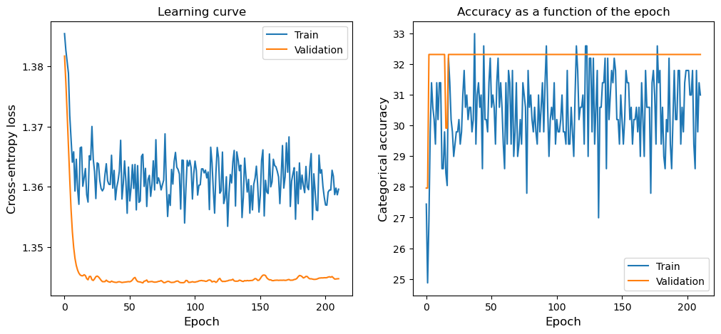

```python
# Plot the learning curves

fig = plt.figure(figsize=(12, 5))

fig.add_subplot(121)
plt.plot(ib_history['training_loss'], label='Train')
plt.plot(ib_history['validation_loss'], label='Validation')
plt.xlabel("Epoch", size=12)
plt.ylabel("Cross-entropy loss", size=12)
plt.title("Learning curve")
plt.legend()

fig.add_subplot(122)
plt.plot(ib_history['training_accuracy'], label='Train')
plt.plot(ib_history['validation_accuracy'], label='Validation')
plt.xlabel("Epoch", size=12)
plt.ylabel("Categorical accuracy", size=12)
plt.title("Accuracy as a function of the epoch")
plt.legend()

plt.show()
```

```python
# Get the model predictions ### need to train on the full data
preds = ib_model(torch.tensor(Images_test, dtype=torch.float32)).detach().numpy()
pred_class = [np.argmax(preds[i, :]) for i in range(preds.shape[0])]
accuracy_vector = (pred_class == Classes_test)
print("the classification accuracy on the test set is", accuracy_vector.sum()/len(accuracy_vector))
```

```
the classification accuracy on the test set is 0.25
```

The classifcation accuracy on the test set is just 0.25, as there are four classes, effectively the CNN is performance is just randomly guessing the classes, the trainning converggence is very bad as well, as ween in the traning history, there is simply no convergence of the trainning(even for the trainning set) and the categorial accuracy didn't really improve as training goes on, also the trainning encounter an early stopping criteria indicating the trainning doesn't have trainning at all. This can be briefly explained by the fact that the traditional which is unweighted, will always have bias towards the majority class, making it bias towards the class that are with more data.

A common way to deal with unbalanced data is just to addjust more weight to that class, as it will force the CNN to train more on the minority class, an obvious method in this case is to adjust the weight inversely propotionally to the weight of the class.

```python
#reweighted loss function

#a vector that represent the data that are in the minioriy class(3)
train3_bool = Classes_train == 3
train3_len = train3_bool.sum()

#weighted_vector(a vector that contains all the weight of different class(inversely propotional to size))
weighted_vector = []
for i in range(4):
    train_bool = ib_Classes_train == i
    weighted_vector.append(train_bool.sum())

weighted_vector = [1/weighted_vector[i] for i in range(4)]
```

```python
def get_model_with_weight(x_train, first_filters, second_filters, kernel_size, pool_size, stride_pool, classes, weight, l2_reg=1e-3):
    """
    CNN model in PyTorch:
    - Layers are Conv2d(+ReLU), MaxPool2d, Conv2d(+ReLU), Flatten and Linear(+Softmax).
    - It features an Adam optimiser and CrossEntropyLoss criterion.
    - Conv2d and Linear layers have regularised weights according to l2_reg.

    Parameters:
    x_train: Training data
    first_filters: Number of filters to be used in the first convolutional layer
    second_filters: Number of filters to be used in the second convolutional layer
    k: Kernel size in the convolutional layer
    pool_size: MaxPool1d window size
    stride_pool: Stride of the MaxPool1d sliding window
    classes: List containing the output classes
    weight: a weight vector which is inversely propotional to the size of the class in the data set
    l2_reg: Positive float corresponding to the regularisation coefficient of Conv1d and Linear

    Returns:
    Model, criterion and optimiser.

    """
    k = np.asarray(kernel_size)
    p = np.asarray(pool_size)
    l_out_conv1 = [x_train.shape[2], x_train.shape[3]] - k + [1, 1] # dimention after first Conv2d (note that the stride is 1)
    l_out_pool = (l_out_conv1 - p) // stride_pool + [1, 1] # Length after MaxPool2d
    l_out_conv2 = l_out_pool - k + [1, 1]
    l_in_linear = second_filters * l_out_conv2[0] * l_out_conv2[1] # Size before Linear layer

    model = Sequential(
        Conv2d(1, first_filters, kernel_size=(5, 5)),
        ReLU(),
        MaxPool2d(kernel_size=pool_size, stride=stride_pool),
        Conv2d(first_filters , second_filters, kernel_size=(5, 5)),
        ReLU(),
        Flatten(),
        Linear(l_in_linear, len(classes)),
        Softmax(dim=1),
    )
    # L2 regularisation
    if l2_reg != 0:
        for layer in model.children():
            if isinstance(layer, Conv2d):
                 layer.weight_regularizer = Parameter(l2_reg * torch.ones_like(layer.weight))

    criterion = CrossEntropyLoss(weight=weight) #adjusting the loss function by reweighting the weight of each class inversly prootial ot class size
    optimiser = torch.optim.Adam(model.parameters())


    return model, criterion, optimiser
```

```python
#make weight_vector into a tensor
weighted_vector_tensor = torch.tensor(weighted_vector, dtype=torch.float32)


# Run the function to get the new model and print it

first_filters = 4
second_filters = 8
kernel_size = (5, 5)
pool_size = (2, 2)
stride_pool = 2
l2_reg = 0
classes = np.unique(Classes_tr)

ib_weighted_model, criterion, optimiser = get_model_with_weight(ib_Images_tr, first_filters, second_filters, kernel_size, pool_size, stride_pool, classes, weighted_vector_tensor, l2_reg)
print(ib_weighted_model)
```

```
Sequential(
  (0): Conv2d(1, 4, kernel_size=(5, 5), stride=(1, 1))
  (1): ReLU()
  (2): MaxPool2d(kernel_size=(2, 2), stride=2, padding=0, dilation=1, ceil_mode=False)
  (3): Conv2d(4, 8, kernel_size=(5, 5), stride=(1, 1))
  (4): ReLU()
  (5): Flatten(start_dim=1, end_dim=-1)
  (6): Linear(in_features=800, out_features=4, bias=True)
  (7): Softmax(dim=1)
)
```

```python
# Calling the training loop
np.random.seed(0)
max_num_epochs = 2000
max_patience = 150

ib_weight_history = training_loop(ib_weighted_model, ib_train_loader, ib_val_loader, max_num_epochs, max_patience)
```

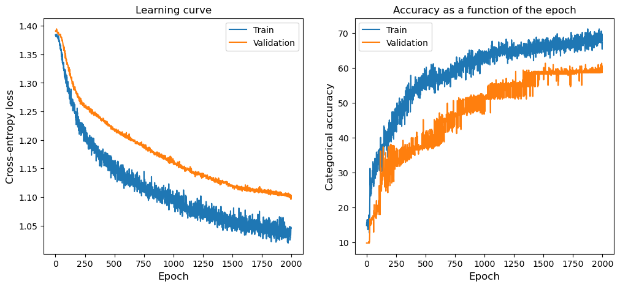

```python
# Plot the learning curves

fig = plt.figure(figsize=(12, 5))

fig.add_subplot(121)
plt.plot(ib_weight_history['training_loss'], label='Train')
plt.plot(ib_weight_history['validation_loss'], label='Validation')
plt.xlabel("Epoch", size=12)
plt.ylabel("Cross-entropy loss", size=12)
plt.title("Learning curve")
plt.legend()

fig.add_subplot(122)
plt.plot(ib_weight_history['training_accuracy'], label='Train')
plt.plot(ib_weight_history['validation_accuracy'], label='Validation')
plt.xlabel("Epoch", size=12)
plt.ylabel("Categorical accuracy", size=12)
plt.title("Accuracy as a function of the epoch")
plt.legend()
plt.show()
```

```python
# Get the model predictions ### need to train on the full data
preds = ib_weighted_model(torch.tensor(Images_test, dtype=torch.float32)).detach().numpy()
pred_class = [np.argmax(preds[i, :]) for i in range(preds.shape[0])]
accuracy_vector = (pred_class == Classes_test)
print("the classification accuracy on the test set is", accuracy_vector.sum()/len(accuracy_vector))
```

```
the classification accuracy on the test set is 0.75
```

The result of the reweighted training accuracy significantly improve the categorial accurucy of the testing set, as 0.75 acccuray is much better than a blinded guess of 0.25 accurucy, we can see that the trainning converge better comparing to the case of unweighted trainning loss model, as we can see the trainning loss (cross entropy) decay excpoentially, although the trainning performance is still as not as the case where we have balanced data(1.1) as the categorial accurcy of the validation converge at around 0.6(in case 1.1 we have the catergoial accurcy converge at around 0.8). The improvement of performance of the CNN model can be explained by that the loss function is value the imbalanced class more(class 3) as it has more weight, therefore, it is not as unbiased towards the majority class.

For the data augumentation method, first I will collect all the data that are in the underpresented class and then, for each c value we will create a gussian noice and create a new set of data by adding the gussian noice to the underrepesented class data that is left in the imbalnced data set, then we will train the model using this new data set and test the accurcy to the validation set to find the best c value, and then we will train the CNN model again using the new data set created with the optimal c value we found as above and report the accurcy on the oringal test case.

```python
#data augmentation:

#we first find the data that are in type 3
pos_3_class = [i for i in range(Nib) if ib_Classes_train[i] == 3]
ib_class3_data = ib_Images_train[pos_3_class, :, : ,:]
```

```python
miu = np.var(ib_class3_data) # calcualte the variance of pixel across the images
print(miu)
```

```
5.833288042100293e-05
```

```python
c_value = [0.01, 0.1, 1] # different value of c testing
best_acu = 0 #initializing the best accuracy
best_cvalue = 0.01 #iniitalizing the best c_value

#finding the best value of c
for i in range(len(c_value)):
    ib_class3_data_tmp = ib_class3_data.copy()
    np.random.seed(0)

    #creating gussian noice
    noice = np.random.normal(0, np.sqrt(c_value[i]*miu), (ib_class3_data.shape[0], ib_class3_data.shape[2], ib_class3_data.shape[3]))

    #creating new data by adding gussian noice to the original class 3 data
    for j in range(ib_class3_data.shape[0]):
        for k in range(ib_class3_data.shape[2]):
            for l in range(ib_class3_data.shape[3]):
                ib_class3_data_tmp[j, 0, k, l] += noice[j, k, l]
    ib_Images_train_tmp = ib_Images_train.copy()
    ib_Images_train_tmp = np.vstack((ib_Images_train_tmp, ib_class3_data_tmp))
    ib_Classes_train_tmp = list(ib_Classes_train.copy())
    for j in range(ib_class3_data_tmp.shape[0]):
        ib_Classes_train_tmp.append(3)
    ib_Classes_train_tmp = np.asarray(ib_Classes_train_tmp)

    #resuffle the data to guarantee that the data are arranged randomly
    np.random.seed(0)
    permutation = np.random.choice(len(ib_Images_train_tmp), size=len(ib_Images_train_tmp), replace=False)
    ib_Classes_train_tmp = ib_Classes_train_tmp[permutation]
    ib_Images_train_tmp = ib_Images_train_tmp[permutation, :, : , :]

    #split the data
    split_rate = 0.75
    ib_Images_tr, ib_Images_val = np.split(ib_Images_train_tmp, [int(split_rate*Nib)])
    ib_Classes_tr, ib_Classes_val = np.split(ib_Classes_train_tmp, [int(split_rate*Nib)])

    #create model to avoid trainning a trained model
    first_filters = 4
    second_filters = 8
    kernel_size = (5, 5)
    pool_size = (2, 2)
    stride_pool = 2
    l2_reg = 0
    classes = np.unique(Classes_tr)

    ib_model, criterion, optimiser = get_model(ib_Images_train_tmp, first_filters, second_filters, kernel_size, pool_size, stride_pool, classes, l2_reg)

    # Numpy arrays to PyTorch tensors
    ib_Images_tr_tensor = torch.tensor(ib_Images_tr, dtype=torch.float32)
    ib_Classes_tr_tensor = torch.tensor(ib_Classes_tr, dtype=torch.long)
    ib_Images_val_tensor = torch.tensor(ib_Images_val, dtype=torch.float32)
    ib_Classes_val_tensor = torch.tensor(ib_Classes_val, dtype=torch.long)

    # Creating training and validation datasets
    ib_train_dataset = TensorDataset(ib_Images_tr_tensor, ib_Classes_tr_tensor.squeeze())
    ib_val_dataset = TensorDataset(ib_Images_val_tensor, ib_Classes_val_tensor.squeeze())

    # Creating corresponding DataLoaders
    ib_train_loader = DataLoader(ib_train_dataset, batch_size=128, shuffle=True)
    ib_val_loader = DataLoader(ib_val_dataset, batch_size=128, shuffle=False)

    #trainning
    # Calling the training loop
    np.random.seed(0)
    max_num_epochs = 2000
    max_patience = 150

    ib_weight_history = training_loop(ib_model, ib_train_loader, ib_val_loader, max_num_epochs, max_patience, printing_or_not=False)

    # Get the model predictions
    preds = ib_model(ib_Images_val_tensor).detach().numpy()
    pred_class = [np.argmax(preds[i, :]) for i in range(preds.shape[0])]

    #calculating the accurucy on the validation set
    accuracy_vector = (pred_class == ib_Classes_val)
    print("the classification accuracy on the test set is", accuracy_vector.sum()/len(accuracy_vector))
    if accuracy_vector.sum()/len(accuracy_vector) > best_acu:
        best_acu = accuracy_vector.sum()/len(accuracy_vector)
        best_cvalue = c_value[i]
```

```
the classification accuracy on the test set is 0.8026905829596412
the classification accuracy on the test set is 0.8295964125560538
Early stopping acting.
the classification accuracy on the test set is 0.30493273542600896
```

```python
print(best_cvalue)
```

```
0.1
```

```python
#train the CNN model for the whole trainning set with the best c-value
ib_class3_data_tmp = ib_class3_data.copy()

#creating gussian noice
np.random.seed(0)
noice = np.random.normal(0, np.sqrt(best_cvalue*miu), (ib_class3_data.shape[0], ib_class3_data.shape[2], ib_class3_data.shape[3]))

#creating new data by adding gussian noice to the original class 3 data
for j in range(ib_class3_data.shape[0]):
    for k in range(ib_class3_data.shape[2]):
        for l in range(ib_class3_data.shape[3]):
            ib_class3_data_tmp[j, 0, k, l] += noice[j, k, l]
ib_Images_train_tmp = ib_Images_train.copy()
ib_Images_train_tmp = np.vstack((ib_Images_train_tmp, ib_class3_data_tmp))
ib_Classes_train_tmp = list(ib_Classes_train.copy())
for j in range(ib_class3_data_tmp.shape[0]):
    ib_Classes_train_tmp.append(3)
ib_Classes_train_tmp = np.asarray(ib_Classes_train_tmp)

#resuffle the data to guarantee that the data are arranged randomly
np.random.seed(0)
permutation = np.random.choice(len(ib_Images_train_tmp), size=len(ib_Images_train_tmp), replace=False)
ib_Classes_train_tmp = ib_Classes_train_tmp[permutation]
ib_Images_train_tmp = ib_Images_train_tmp[permutation, :, : , :]

#split the data
split_rate = 0.75
ib_Images_tr, ib_Images_val = np.split(ib_Images_train_tmp, [int(split_rate*Nib)])
ib_Classes_tr, ib_Classes_val = np.split(ib_Classes_train_tmp, [int(split_rate*Nib)])

#create model so that we won't train on a trained model
first_filters = 4
second_filters = 8
kernel_size = (5, 5)
pool_size = (2, 2)
stride_pool = 2
l2_reg = 0
classes = np.unique(Classes_tr)

ib_opt_model, criterion, optimiser = get_model(ib_Images_train_tmp, first_filters, second_filters, kernel_size, pool_size, stride_pool, classes, l2_reg)

# Numpy arrays to PyTorch tensors
ib_Images_tr_tensor = torch.tensor(ib_Images_tr, dtype=torch.float32)
ib_Classes_tr_tensor = torch.tensor(ib_Classes_tr, dtype=torch.long)
ib_Images_val_tensor = torch.tensor(ib_Images_val, dtype=torch.float32)
ib_Classes_val_tensor = torch.tensor(ib_Classes_val, dtype=torch.long)

# Creating training and validation datasets
ib_train_dataset = TensorDataset(ib_Images_tr_tensor, ib_Classes_tr_tensor.squeeze())
ib_val_dataset = TensorDataset(ib_Images_val_tensor, ib_Classes_val_tensor.squeeze())

# Creating corresponding DataLoaders
ib_train_loader = DataLoader(ib_train_dataset, batch_size=128, shuffle=True)
ib_val_loader = DataLoader(ib_val_dataset, batch_size=128, shuffle=False)

#trainning
# Calling the training loop
np.random.seed(0)
max_num_epochs = 2000
max_patience = 150

ib_weight_history = training_loop(ib_opt_model, ib_train_loader, ib_val_loader, max_num_epochs, max_patience, printing_or_not=False)
```

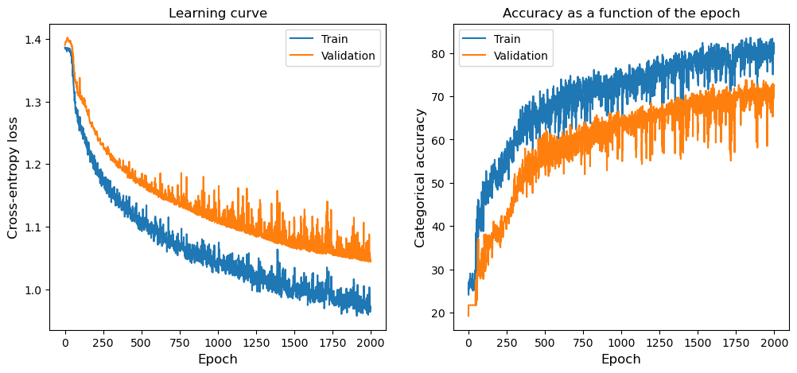

```python
# Plot the learning curves

fig = plt.figure(figsize=(12, 5))

fig.add_subplot(121)
plt.plot(ib_weight_history['training_loss'], label='Train')
plt.plot(ib_weight_history['validation_loss'], label='Validation')
plt.xlabel("Epoch", size=12)
plt.ylabel("Cross-entropy loss", size=12)
plt.title("Learning curve")
plt.legend()

fig.add_subplot(122)
plt.plot(ib_weight_history['training_accuracy'], label='Train')
plt.plot(ib_weight_history['validation_accuracy'], label='Validation')
plt.xlabel("Epoch", size=12)
plt.ylabel("Categorical accuracy", size=12)
plt.title("Accuracy as a function of the epoch")
plt.legend()
plt.show()
```

```python
# Get the model predictions ### need to train on the full data
preds = ib_opt_model(torch.tensor(Images_test, dtype=torch.float32)).detach().numpy()
pred_class = [np.argmax(preds[i, :]) for i in range(preds.shape[0])]
accuracy_vector = (pred_class == Classes_test)
print("the classification accuracy on the test set is", accuracy_vector.sum()/len(accuracy_vector))
```

```
the classification accuracy on the test set is 0.875
```

# (2) Task 2: Dimensionality Reduction: PCA vs ISOMAP (index)

## (2.1) (index)

In this task, I will first standardize the data and then create PCA matrix for the first two eigenvector, plot of the coordinate for those eigenvector and discuss whether it create a good 'clustering', using the DB index.

```python
def standardise(X):
    """
    Arguments:
    X: Data with samples being indexed along axis 0.

    Returns:
    Xbar: Standardised data.

    """
    mu = np.mean(X, axis=0)
    std = np.std(X, axis=0)
    Xbar = (X - mu) / std

    return Xbar
```

```python
#standardize data
Embeds_train_std = standardise(Embeds_train)
```

```python
## EDIT THIS FUNCTION

def covariance_matrix(X):
    """
    Arguments:
    X: Data with samples being indexed along axis 0.

    Returns:
    Xbar: Computes the data covariance matrix.

    """
    return np.dot(X.T, X) / len(X)

def pca_function(X, k):
    """
    Arguments:
    X: Data with samples being indexed along axis 0.
    k: Number of principal components.

    Returns:
    X_pca: Transformed data.
    eigenvectors: First k eigenvectors of C.
    eigenvalues: First k eigenvalues of C.

    """
    # Computing the covariance matrix
    C = covariance_matrix(X)

    # Computing the eigenvalues and eigenvectors using the eigsh scipy function
    eigenvalues, eigenvectors = linalg.eigsh(C, k, which='LM', return_eigenvectors=True)

    # Sorting the eigenvectors and eigenvalues from largest to smallest eigenvalue


    # Projecting the data onto the directions of eigenvectors
    X_pca = X.dot(eigenvectors)

    return X_pca, eigenvectors, eigenvalues
```

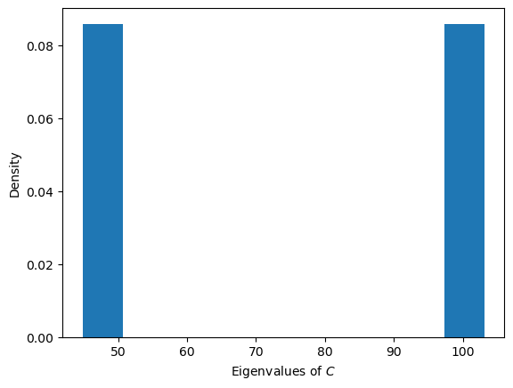

```
[ 44.86399 103.09516]
```

```python
k = 2
Embeds_pca, eigenvectors, eigenvalues = pca_function(Embeds_train_std, k)

# If we look at the spectrum, the large values indicate there is some signal of significant correlations

plt.hist(eigenvalues, density=True);
plt.xlabel('Eigenvalues of $C$')
plt.ylabel('Density')
plt.show()
print(eigenvalues)
```

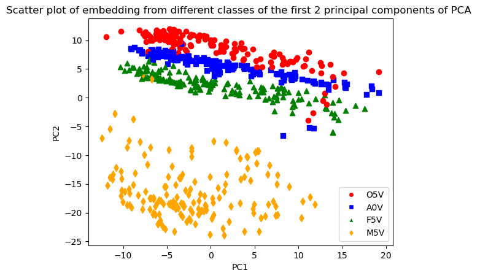

```python
#initialize for the color
type_colors = {0:'red', 1:'blue', 2:'green', 3:'orange'} #setting each type with a color
type_markers = {0:'o', 1:'s', 2:'^', 3:'d'} #color-blinded friendly
star_label ={0:'O5V', 1:'A0V', 2:'F5V', 3:'M5V'}

for i in range(N):
    plt.scatter(Embeds_pca[i, 0], Embeds_pca[i, 1], color=type_colors[Classes_train[i]], marker=type_markers[Classes_train[i]])

# Add legend
legend_handles = []
for class_label, label_text in star_label.items():
    legend_handles.append(plt.Line2D([0], [0], marker=type_markers[class_label], color='w', label=label_text, markerfacecolor=type_colors[class_label]))

# Add legend
plt.legend(handles=legend_handles)

plt.title('Scatter plot of embedding from different classes of the first 2 principal components of PCA ')

plt.xlabel('PC1')
plt.ylabel('PC2')
```

```python
def compute_avg_within_distance(centroids, X, labels):
    """
    Compute the within-cluster distance.

    Args:
        centroids (np.ndarray): the centroids array, with shape (k, p).
        X (np.ndarray): the samples array, with shape (N, p).
        labels (np.ndarray): the cluster index of each sample, with shape (N,).

    Retruns:
        (np.ndarray): the  avg within-cluster distance of each cluster.
    """
    within_distance = []
    k, p = centroids.shape

    for l in range(k):
        tmp = 0
        centroid = centroids[l, :]
        # Applying aggregate computations on `NaN` values
        # can propagate the `NaN` to the results.
        # In this case we skip the `NaN` centroid,
        # which is effectively of an empty cluster.
        if np.isnan(centroid).any():
            continue

        # Select samples belonging to label=l.
        X_cluster = X[labels == l]


        distances = np.linalg.norm(X_cluster - centroid, axis=1)

        # Compute the average distance within the cluster.
        avg_distance = np.mean(distances)

        within_distance.append(avg_distance)

    return within_distance
```

```python
def compute_centroids(k, X, labels):
    """
    Compute the centroids of the clustered points X.

    Args:
        k (int): total number of clusters.
        X (np.ndarray): data points, with shape (N, p)
        labels (np.ndarray): cluster assignments for each sample in X, with shape (N,).

    Returns:
        (np.ndarray): the centroids of the k clusters, with shape (k, p).
    """
    N, p = X.shape

    centroids = np.zeros((k, p))

    for label in range(k):
        cluster_X_l = X[labels == label]
        centroids[label] = cluster_X_l.mean(axis=0)

    return centroids
```

```python
def DB_index(k, X, labels):
    """
    Compute the DB index for the data set X.

    Args:
        k (int): total number of clusters.
        X (np.ndarray): data points, with shape (N, p)
        labels (np.ndarray): cluster assignments for each sample in X, with shape (N,).

    Returns:
        (float): the DB index of the data set X.
    """
    # we first calculate the centroid of each label
    X_centroid = compute_centroids(k, X, labels)
    X_avg_distance = compute_avg_within_distance(X_centroid, X, labels)
    DB = 0
    fab = 0
    for i in range(k):
        tmp_max = 0
        for j in range(k):
            if i != j:
                fab = (X_avg_distance[i] + X_avg_distance[j])/(np.linalg.norm(X_centroid[i, :] - X_centroid[j, :]))
            if fab > tmp_max:
                tmp_max = fab
        DB += tmp_max
    DB = DB/k
    return DB
```

```python
print('The DB index of the Class cluster is ', DB_index(4, Embeds_pca, Classes_train))
```

```
The DB index of the Class cluster is  2.8533684715449037
```

To Check whether the DB index is correct we create a plot with the centroid of different classes ploted.

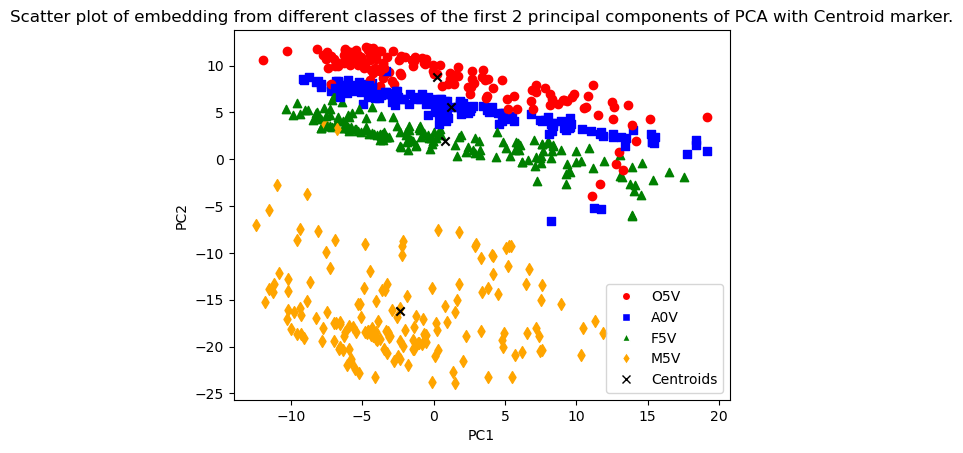

```python
#initialize for the color
type_colors = {0:'red', 1:'blue', 2:'green', 3:'orange'} #setting each type with a color
type_markers = {0:'o', 1:'s', 2:'^', 3:'d'} #color-blinded friendly
star_label ={0:'O5V', 1:'A0V', 2:'F5V', 3:'M5V'}

for i in range(N):
    plt.scatter(Embeds_pca[i, 0], Embeds_pca[i, 1], color=type_colors[Classes_train[i]], marker=type_markers[Classes_train[i]])

# Add legend
legend_handles = []
for class_label, label_text in star_label.items():
    legend_handles.append(plt.Line2D([0], [0], marker=type_markers[class_label], color='w', label=label_text, markerfacecolor=type_colors[class_label]))
legend_handles.append(plt.Line2D([0], [0], marker='x', color='black', linestyle='', label='Centroids', markerfacecolor='black'))


#add Centroid
centroids = compute_centroids(4, Embeds_pca, Classes_train)
for i, centroid in enumerate(centroids):
    plt.scatter(centroid[0], centroid[1], color='black', marker='x')

# Add legend
plt.legend(handles=legend_handles)

plt.title('Scatter plot of embedding from different classes of the first 2 principal components of PCA with Centroid marker.')

plt.xlabel('PC1')
plt.ylabel('PC2')
```

The position of the centroid of each class does looks like around the middle of the each class.

```python
print(compute_avg_within_distance(centroids, Embeds_pca, Classes_train))
```

```
[6.0407407632637815, 6.031098111914224, 6.378069835333725, 6.4872677438643604]
```

| Classes type | Avg within distance within Classes |
| --- | --- |
| O5V | 6.04 |
| A0V | 6.03 |
| F5V | 6.38 |
| M5V | 6.49 |

DB index is a ratio between the sum of avg within distance within classes and the distance between the centroid of the classes, as we can see from the above table and from the plot the classses are quite spread along horizontally for class O5V, A0V, F5V and quite spread around in general for class M5V, so the avg withindistance is quite large(meaning the variance of each classes is quite huge) while as we can observe from the above plot that the centroids are quite close tgt for the class O5V, A0V, F5V, meaning the classes has not a very significant speration, resulting quite a high DB-index, meaning that the classes are not a very good clustering in this case.

Also Note that PCA is a linear method, therefore we can see the seperation between different class is quite 'linear', as they seems to be parallel to each other.

## (2.2) (index)

In this task, I will do the first step of the Isomap algorithm by construting a weighted graph of KNN neighbour, by first calucalteting the cosine distance matrix, then we will construct the weighted Adjancency matrix, of the 9 nearest neighbour of the nodes and then I will plot the graph using the normalzied third eigenvector entries against the normalized fiedler eigenvector entries and I will discuss using the above plot whether there is a good bipartician of the classes.

```python
#compute the matrix D(distance matrix)

D = np.zeros((N, N))
for i in range(N):
    for j in range(N):
        D[i, j] = 1 - np.dot(Embeds_train[i, :], Embeds_train[j, :])/ (np.linalg.norm(Embeds_train[i, :])*np.linalg.norm(Embeds_train[j, :]))
```

```python
# Compute the ajaceny matrix A of the k = 9 NN for the graph
A = np.zeros((N, N))
for i in range(N):
    sorted_indices = np.argsort(D[i, :]) #find the index of the neighbour
    neighbours = sorted_indices[1:10] #find the index for the 9  nearest neighbour
    for j in neighbours:
        A[i, j] = D[i, j]
        A[j, i] = D[i, j]
```

```python
# compute weighted degrees
d = A.sum(axis=0)
```

```python
D = np.diag(d)

# compute combinatorial weighted Laplacian
L = D - A

# compute square root of inverse diagonal degree matrix
D_sqrt_inv = np.diag(1/np.sqrt(d))

# compute symmetric normalised Laplacian
L_s = D_sqrt_inv @ L @ D_sqrt_inv
```

```python
# compute eigen decomposition using the fact that
eigenvals, eigenvecs = np.linalg.eigh(L_s)

# sort eigenvalues and corresponding eigenvector
eigenvecs = eigenvecs.T[np.argsort(eigenvals)]
eigenvals = np.sort(eigenvals)
```

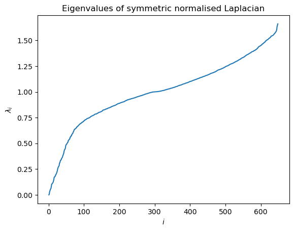

```python
# plot eigenvalues
fig, ax = plt.subplots(1)
ax.plot(np.arange(1,N+1),eigenvals)
ax.set(title="Eigenvalues of symmetric normalised Laplacian",xlabel=r"$i$",ylabel=r"$\lambda_i$")
plt.show()
```

```python
# print first and second eigenvalues
print("First eigenvalue:", round(eigenvals[0],5))
print("Second eigenvalue:", round(eigenvals[1],5))
```

```
First eigenvalue: 0.0
Second eigenvalue: 0.00556
```

```python
# get second (Fiedler) and third eigenvectors
v2 = eigenvecs[1]
v3 = eigenvecs[2]

# normalise coordinates
x = D_sqrt_inv @ v2
y = D_sqrt_inv @ v3
```

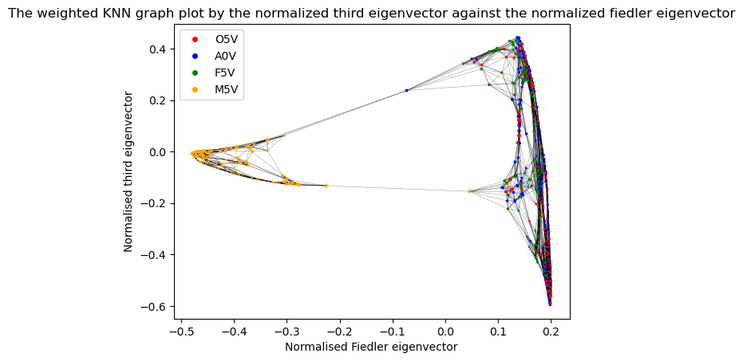

```python
# plot
fig, ax = plt.subplots(1)
type_colors = {0:'red', 1:'blue', 2:'green', 3:'orange'} #setting each type with a color
type_markers = {0:'o', 1:'s', 2:'^', 3:'d'} #color-blinded friendly
star_label ={0:'O5V', 1:'A0V', 2:'F5V', 3:'M5V'}
colors = [type_colors[i]  for i in Classes_train]
# plot edges
for i in range(N):
    for j in range(i+1,N):
        if A[i,j] > 0:
            ax.plot([x[i],x[j]],[y[i],y[j]], color="black", alpha=0.5, linewidth=0.3)

# plot nodes
scatter = ax.scatter(x,y,s=50*d, c=colors, zorder=10)

legend_handles = []
for class_label, label_text in star_label.items():
    legend_handles.append(plt.Line2D([0], [0], marker=type_markers[0], color='w', label=label_text, markerfacecolor=type_colors[class_label]))

# Add legend
plt.legend(handles=legend_handles)


# set labels
ax.set(xlabel="Normalised Fiedler eigenvector", ylabel="Normalised third eigenvector")
plt.title('The weighted KNN graph plot by the normalized third eigenvector against the normalized fiedler eigenvector')
plt.show()
```

We observe that the star Class M5V is cluster togeather with a very sall nromalised fiedler eigenvector value(< -0.3) while the other three class, while the other three class are mostly cluster togeather with a comparingly larger normalized fiedler eigenvetor value(> 0), which suggest that these four star classes it may be natrually to biparticion them into two cluster with M5V being it owns cluster(as ususally the way we bypartician classes is by consider the magnitude of the entries of the normalized fiedler eigenvector), and the other three class should be in the same cluster, which make sense as the class M5V is the coolest class around all class so it may have some properties that it need to be seperate from the other classes.

## (2.3) (index)

In this task I will first calcualte the pairwise geodesic distance of the node by calcualte the matrix Tau and R, then we will apply multidimentioanl scaling to the matrix S which is the pointwise square of R and mulitple it with H, then I will visualize the graph using the top two eigenvecotr of the matrix tau and comment on its clustering performance by carrying out the DB index.

```python
#calculate the Tau matrix
Tau = np.linalg.pinv(L - (1/N) * np.ones((N, N)))
```

```python
#calcualte the Residence matrix R
R = np.zeros((N, N))
for i in range(N):
    for j in range(N):
        R[i, j] = Tau[i, i] + Tau[j, j] - 2*Tau[i, j]
```

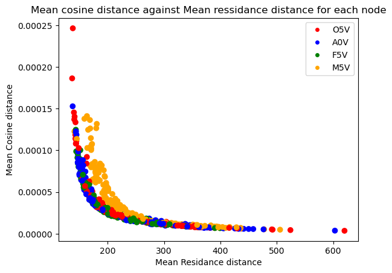

```python
#plot
cos_dist = np.mean(D, axis = 1)
r_dist = np.mean(R, axis = 1)

fig, ax = plt.subplots()
colors = [type_colors[i]  for i in Classes_train]
scatter = ax.scatter(r_dist, cos_dist, c=colors, zorder=10)
legend_handles = []
for class_label, label_text in star_label.items():
    legend_handles.append(plt.Line2D([0], [0], marker=type_markers[0], color='w', label=label_text, markerfacecolor=type_colors[class_label]))

# Add legend
plt.legend(handles=legend_handles)

#set title
ax.set_title("Mean cosine distance against Mean ressidance distance for each node")
# set labels
ax.set(xlabel="Mean Residance distance", ylabel="Mean Cosine distance")
plt.show()
```

I first notice that the magnitude of the Mean Cosine distance is much smaller the Mean residance, as the mean ressidance is the mean of the pairwise geodesic distance between nodes, and we only connected the nodes which $D_{ij}$ is the 9th smallest(or smaller) for either i, j, so the geodesic distance should be much larger than the mean cosine distance.

Secondlly, I found out that the mean cosine distance is inversely propotional to the mean residance distance, which make sense from the formula as N is very large, $\Tau$ is approximately the inverse of L matrix so we would expect that, the order of element is inversely propotional of the order of element of the L matrix (which is the same order as D), therefore the order mean cosine distance of should be 1/ the order of the mean resideance distance, as we are taking a mean of a lot of element that the order should be inversely propotional.

```python
#compute the H matrix
H = np.eye(N) -1/N * np.ones((N, N))
```

```python
#compute the S matrix
S = np.zeros((N, N))
for i in range(N):
    for j in range(N):
        S[i, j] = R[i, j]**2
```

```python
#compute the tau matrix
tau = -1/2 * H @ S @ H
```

```python
# compute eigen decomposition using the fact that tau is also symmetic
tau_eigenvals, tau_eigenvecs = np.linalg.eigh(tau)
# sort eigenvalues and corresponding eigenvector
tau_eigenvecs = tau_eigenvecs.T[np.argsort(tau_eigenvals)]
tau_eigenvals = np.sort(tau_eigenvals)
```

```python
#compute the top 2 eigenvector
v1 = tau_eigenvecs[-1]
v2 = tau_eigenvecs[N-2]
x = v1
y = v2
v1 = v1.reshape(-1, 1)
v2 = v2.reshape(-1, 1)
tau_data = np.hstack((v1, v2))
```

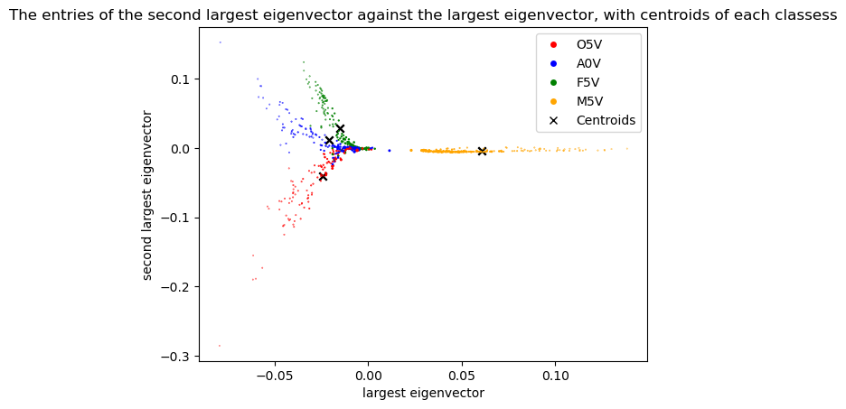

```python
# plot
fig, ax = plt.subplots(1)
type_colors = {0:'red', 1:'blue', 2:'green', 3:'orange'} #setting each type with a color
type_markers = {0:'o', 1:'s', 2:'^', 3:'d'} #color-blinded friendly
star_label ={0:'O5V', 1:'A0V', 2:'F5V', 3:'M5V'}
colors = [type_colors[i]  for i in Classes_train]


# plot nodes
scatter = ax.scatter(x,y,s=20*d, c=colors, zorder=10)

legend_handles = []
for class_label, label_text in star_label.items():
    legend_handles.append(plt.Line2D([0], [0], marker=type_markers[0], color='w', label=label_text, markerfacecolor=type_colors[class_label]))
legend_handles.append(plt.Line2D([0], [0], marker='x', color='black', linestyle='', label='Centroids', markerfacecolor='black'))

#plot centroids
centroids = compute_centroids(4, tau_data, Classes_train)
for i, centroid in enumerate(centroids):
    plt.scatter(centroid[0], centroid[1], color='black', marker='x')

for i, centroid in enumerate(centroids):
    plt.scatter(centroid[0], centroid[1], color='black', marker='x')


# Add legend
plt.legend(handles=legend_handles)

# set labels
ax.set_title('The entries of the second largest eigenvector against the largest eigenvector, with centroids of each classess')
ax.set(xlabel="largest eigenvector", ylabel="second largest eigenvector")
plt.show()
```

```python
x = x.reshape(-1, 1) #reshape the eigenvector
y = y.reshape(-1, 1)
tau_rep = np.hstack((x, y)) #create a new representation that we can calculate the DB index
```

```python
print('The DB index of the different classes of this representation is ', DB_index(4, tau_data, Classes_train))
```

```
The DB index of the different classes of this representation is  1.9399147256266378
```

```python
print(compute_avg_within_distance(centroids, tau_data, Classes_train))
```

```
[0.0381247729432776, 0.022312597887678694, 0.03023436242592979, 0.021361727467886015]
```

| Classes type | Avg within distance within Classes |
| --- | --- |
| O5V | 0.038 |
| A0V | 0.022 |
| F5V | 0.030 |
| M5V | 0.021 |

The division of class uisng this presentation is not a very good clustering, as we the DB index > 1(1.9) but an ideal clustering of class should have the mean avg distance within the classes < the distance between centroid(i.e. IB index < 1), which can be seen in the above plot and table as we can see again, the centroid between class O5V, A0V and F5V are quite close tgt and from teh above table we can see that the avg distance within classes, is comparable to the distance between centroid, indicating not a perfect clustering, however we note that the DB index is smaller than the DB index we calcualte in 2.1(1.9 < 2.8) indicating a better clustering, and by comparing the plot of the presentation of the graph in 2.1 to 2.3 we found out that the boudnary seperation of different class is no longer linear, rather it is quite a non-linear boundary, which could be explained by as in this step we are doing multidimentoal scaling and we can see multidimentioal scaling as a generization of PCA(PCA can only deal with eculdian distance), this could explain why it create a better clusterign and the clustering boundary is non-linear comparing to the linear boundary of the PCA case.